# malbacR: A Vignette Pertaining to Unfiltered Data

Damon Leach, Kelly Stratton, Lisa Bramer

2024-01-31

The R package `malbacR` is a new package that deals with batch correction methods of small molecule omics data. It works in conjunction with `pmartR`, an R package designed for preprocessing, filtering, and analyzing multi-omics data (Stratton et al. 2019; Degnan et al. 2023).

This outline demonstrates the functionality and use of the `malbacR` package. Within this package, there are four data sets: `pmart_amide`, `pmart_amideFilt`,`pmart_mix`, and `pmart_mixFilt`. The first two objects contain data originally found in the package `WaveICA2.0` (Deng and Li 2022). The second two objects contain data originally found in the package `crmn` (Redestig et al. 2009). The data sets with the suffix “Filt” are filtered versions of the original data sets. That is, unlike their non-filtered counterparts, these data objects require no additional data manipulation for batch correction to successfully run. For this example, we work with the unfiltered data sets to demonstrate how `pmartR` works with in tandem with `malbacR`.

1. Range Scaling (Berg et al. 2006)
2. Power Scaling (Berg et al. 2006)
3. Pareto Scaling (Berg et al. 2006)
4. ComBat (Müller et al. 2016)
5. EigenMS (Karpievitch et al. 2014)
6. NOMIS (Sysi-Aho et al. 2007)
7. RUV-random (De Livera et al. 2015)
8. QC-RLSC (Dunn et al. 2011)
9. WaveICA2.0 (Deng et al. 2019)
10. TIGER (Han et al. 2022)
11. SERRF (Fan et al. 2019)
12. QC-RFSC (Luan et al. 2018)

First we load in the necessary libraries which is the `malbacR` package itself and `pmartR` (Degnan et al. 2023) which `malbacR` works with compatibly. Additionally, `ggplot2` is loaded for some slight graphical manipulations.

```r
library(malbacR)
library(pmartR)
library(ggplot2)
```

## Data Set 1: Amide Data

The first data set in `malbacR`, `pmart_amide`, is the Amide data set originally found in the package `WaveICA2.0` (Deng and Li 2022). This metabolomics data set was ran in three batches. In this random subset of the Amide data, there are 500 molecules and 642 samples. This data set contains information about the samples regarding batch, group, Quality Control (QC) samples, and injection order. Using this information, we can run batch correction on the data using the following methods: range scaling (Berg et al. 2006), power scaling (Berg et al. 2006), pareto scaling (Berg et al. 2006), ComBat (Müller et al. 2016), EigenMS (Karpievitch et al. 2014), QC-RLSC (Dunn et al. 2011), TIGER (Han et al. 2022), and WaveICA2.0 (Deng et al. 2019). As there is no e_meta information for negative controls or internal standards, NOMIS (Sysi-Aho et al. 2007) and RUV-random (De Livera et al. 2015) cannot be run.

### Load in the Data

A `pmartR` friendly version of the Amide data is already implemented within `malbacR`. Therefore, we simply need to load the data.

```r
data(pmart_amide)
```

Before running batch correction, we run some pre-processing steps. First we specify the group designation of the data with `group` as the `main_effects` and `batch` as the `batch_id`.

Next, we create a version of the data that has been log2 transformed, as some methods (but not all methods) require the data to be on a log scale. Additionally, we create a normalized version of the data using a global median. All of this is done using the functions `group_designation`, `edata_transform`, and `normalize_global` respectively within `pmartR` (Degnan et al. 2023).

```r
pmart_amide <- group_designation(pmart_amide,main_effects = "group",batch_id = "batch")
pmart_amide_log <- edata_transform(pmart_amide,"log2")
pmart_amide_norm <- normalize_global(pmart_amide_log,subset_fn = "all",norm_fn = "median",
                                apply_norm = TRUE,backtransform = TRUE)
```

### Run Batch Correction Methods

##### Scaling Methods

To correct for batch effects using range, power, and pareto scaling, we use the functions `bc_range`, `bc_power`, and `bc_pareto` respectively. All three of these functions simply simply take the parameter `omicsData` which is the S3 data object that is compatible within `pmartR`.

These scaling methods are ran using log2 abundance values that have not been normalized.

```r
# range scaling
amide_range <- bc_range(omicsData = pmart_amide_log)

# power scaling
amide_power <- bc_power(omicsData = pmart_amide_log)

# pareto scaling
amide_pareto <- bc_pareto(omicsData = pmart_amide_log)
```

##### QC-Based Methods

Some batch correction methods rely on Quality Control (QC) samples including TIGER, QC-RLSC, QC-RFSC and SERRF. To run TIGER (Technical variation elImination with ensemble learninG architEctuRe) (Han et al. 2022), we run the function `bc_tiger` and use the following parameters: `omicsData`, `sampletype_cname` (a column in `f_data` that specifies which sample is QC sample or not), `test_val` (the value in `sampletype_cname` that specifies a QC sample), `injection_cname` (the column in `f_data` that specifies the injection order), and `group_cname` (the column in the `f_data` that specifies the groups that are used for statistical analyses).

TIGER requires that there be at least one sample from the QC samples to have complete data for every molecule and at least one sample from the non-QC samples to have complete data from every molecule (Han et al. 2022). For this reason, we include a function, `tiger_filter`, that finds the combination of a QC sample and a non-QC sample that has the the fewest number of missing molecules to determine which molecules need to be removed. Using an additional function `apply_tigerFilt`, we apply that filter and obtain an S3 object that is capable of working within both `pmartR` and `malbacR`. Although this subset of data is already capable of undergoing TIGER batch correction as there is at least one QC sample and at least one non-QC sample with no missing values, we show how these functions would work in general.

TIGER is ran on raw abundance values. After running batch correction, we transform the data to a log2 scale.

```r
tigerFilt <- tiger_filter(pmart_amide,sampletype_cname = "group",test_val = "QC")
pmart_amideFilt <- apply_tigerFilt(tigerFilt,pmart_amide)
amide_tiger_abundance <- bc_tiger(omicsData = pmart_amideFilt,sampletype_cname = "group",
                        test_val = "QC",injection_cname = "Injection_order",group_cname = "group")
amide_tiger <- edata_transform(omicsData = amide_tiger_abundance, data_scale = "log2")
```

QC-RLSC (Quality Control - Robust Loess Signal Correction) (Dunn et al. 2011) can be ran using `bc_qcrlsc` which takes on the parameters `omicsData`, `block_cname` (a column in `f_data` that specifies which column contains batch information), `qc_cname` (a column in in `f_data` that specifies which sample is a QC sample or not), `qc_val` (the value in `qc_cname` that specifies a QC sample), and `order_cname` (a column in `f_data` that specifies the run order of the samples). Additionally, the user can specify the `missing_thresh` (the minimum proportion of observed biomolecules for each QC samples), the `rsd_thresh`, and whether the user wants to `backtransform` the data or not. Further, users can specify whether they would like to retain the QC samples in their final output by specifying `keep_qc` to be TRUE or FALSE.

QC-RLSC is ran on log2 abundance values that have not been normalized.

```r
amide_qcrlsc <- bc_qcrlsc(omicsData = pmart_amide_log,block_cname = "batch",
                          qc_cname = "group", qc_val = "QC", order_cname = "Injection_order",
                          missing_thresh = 0.5, rsd_thresh = 0.3, backtransform  = FALSE,keep_qc = FALSE)
```

The next QC method in `malbacR` is SERRF (Systematic Error Removal using Random Forest) (Fan et al. 2019) which uses the function `bc_serrf`. This function utilizes the parameters `omicsData`, `sampletype_cname`, `test_val`, and `group_cname` which have the same meanings as those within `bc_tiger`.

One thing to note that SERRF is a method that requires complete observations (Fan et al. 2019). This means we either have to remove molecules with missing values or impute them using an Expectation Maximization algorithm. Although there are reasons to avoid imputation particularly with proteomics data (B.-J. Webb-Robertson et al. 2011), we acknowledge that there are cases in which imputation is necessary. Therefore, we include an `imputation` function that returns the `e_data` that has undergone imputation. To then officially apply this to the `pmartR` S3 object, the user runs `apply_imputation`, similar to the procedure of `tiger_filter` and `apply_tigerFilt`.

It is important to note that while SERRF is ran on raw abundance values, imputation is conducted on log2 data. Therefore, users must impute the data using log2 data. Once imputed, users can return to a raw abundance value to run batch correction. After running batch correction, we log2 transform the data again.

```r
impObj <- imputation(omicsData = pmart_amide_log)
amide_imp_log <- apply_imputation(impObj,pmart_amide_log)
amide_imp_raw <- edata_transform(amide_imp_log,"abundance")
```

```r
amide_serrf_abundance <- bc_serrf(omicsData = amide_imp_raw,sampletype_cname = "group",test_val = "QC",group_cname = "group")
amide_serrf <- edata_transform(omicsData = amide_serrf_abundance,data_scale = "log2")
```

The final QC method in `malbacR` is QC-RFSC (Quality Control - Random Forest Signal Correction) (Luan et al. 2018) can be ran using `bc_qcrfsc` which takes on the parameters. QC-RFSC has the following the arguments `omicsData`, `qc_cname`, `qc_val`, `keep_qc` and `Injection_order` which has the same meaning as the arguments from QC-RLSC. Additionally, QC-RFSC requires `group_cname` and `ntree` (the number of trees to be created when running random forest).

Similar to SERRF, QC-RFSC requires complete observations, but is ran on raw abundance values (Luan et al. 2018). As with SERRF, we log2 transform the data, impute the data, transform back to raw abundance values and then run QC-RFSC. To compare results, it is suggested that users then convert data back to log2 scale after batch correction.

```r
amide_qcrfsc_abundance <- bc_qcrfsc(omicsData = amide_imp_raw,qc_cname = "group",qc_val = "QC",
                                    order_cname = "Injection_order",group_cname = "group",
                                    ntree = 500, keep_qc = FALSE)
amide_qcrfsc <- edata_transform(omicsData = amide_qcrfsc_abundance,data_scale = "log2")
```

##### Other Methods

There are other methods that do not utilize a scaling approach or use QC samples. One method is ComBat which relies on an Empirical Bayesian analysis (Müller et al. 2016). ComBat can be ran using `bc_combat` taking on the parameter `omicsData`. However, for this function to run, the user must have normalized the data using `normalize_global` and added a batch ID using `group_designation` within `pmartR`. Further, there is an optional parameter `use_groups` that defaults to `FALSE`. If set to `TRUE`, ComBat will run using both batch and group information rather than just batch information.

ComBat is ran on log2 transformed data that has also been normalized.

```r
# combat batch correction
amide_combat <- bc_combat(omicsData = pmart_amide_norm, use_groups = FALSE)
```

EigenMS uses the function `bc_eigenMS` and takes the parameter `omicsData`. While this is the only parameter, it is also required that the the S3 object has undergone group designation using the function `group_designation` in `pmartR`. However, only a `main_effects` for the group information needs to be addressed and no `batch_id` is necessary. This is in contrast with `bc_combat` which requires `batch_id`.

EigenMS is ran on data that has been log2 transformed, but has not been normalized.

```r
amide_eigen <- bc_eigenMS(omicsData = pmart_amide_log)
```

The final method we demonstrate using the “Amide” data is WaveICA which uses the function `bc_waveica`. Within this function users can either run WaveICA or WaveICA2.0 by specifying the parameter `version` to be either “WaveICA” or “WaveICA2.0”. The default is “WaveICA”.

Like SERRF and QC-RFSC, WaveICA and WaveICA2.0 requires both complete observations and raw abundance values (Deng et al. 2019). Therefore, we use the imputed data set that has already been created and follow a similar procedure of log2 transforming the data to impute the data, converting back to raw abundance values to run batch correction. After batch correction, we log2 transform the data back again.

It is noted that WaveICA can yield negative raw abundance values. When converting to a log2 scale, these values will become NA and may impact downstream analyses. Users can choose to specify `negative_to_na` to be TRUE and all abundance values that are negative will be returned as NA.

```r
amide_wave_abundance <- bc_waveica(omicsData = amide_imp_raw, batch_cname = "batch",
                         version = "WaveICA2.0",
                         injection_cname = "Injection_order",alpha = 0,
                         cutoff_injection = 0.1, K = 10,
                         negative_to_na = TRUE)
amide_wave <- edata_transform(omicsData = amide_wave_abundance, data_scale = "log2")
```

### Amide: Data Visualization

After obtaining all the different batch corrected data sets, we can plot the PPCA (B.-J. M. Webb-Robertson et al. 2013) to see if they are successfully returning batch corrected data. We set the `group_designation` to use our batch information as the `main_effects` so as to color the data by batch. All of this code is run using functions from `pmartR` demonstrating the utility between the two packages. A data set with batch effects will tend to produce a PPCA with distinct clusters for each batch. A good batch effect correction method will reduce those distinct clusters. Using that logic, ComBat, EigenMS, WaveICA2.0, and SERRF perform the best within this data set.

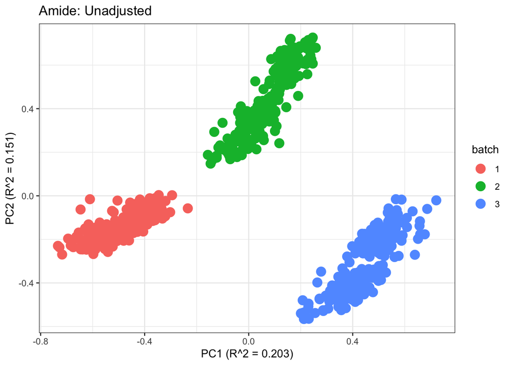

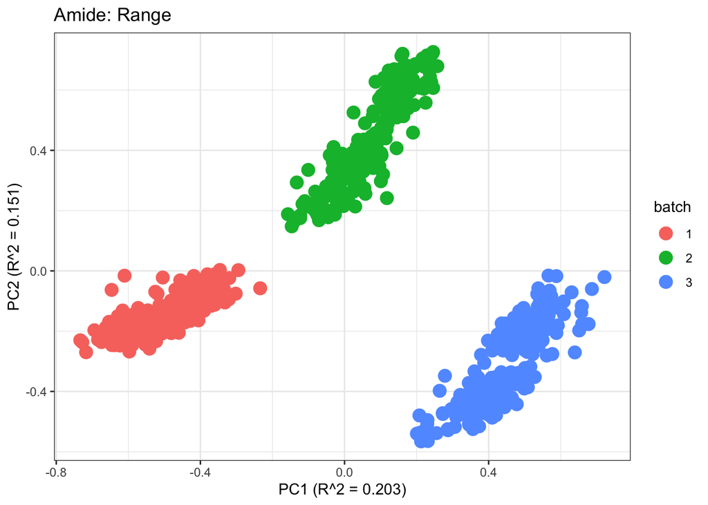

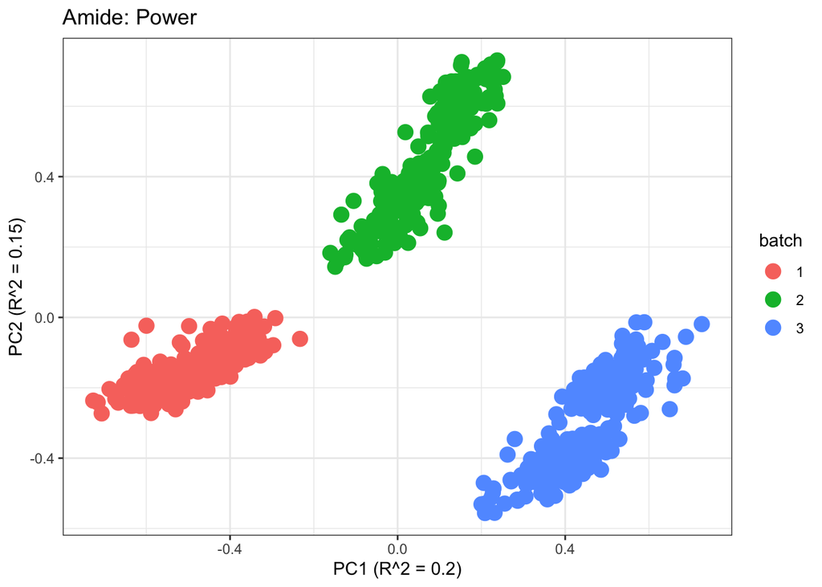

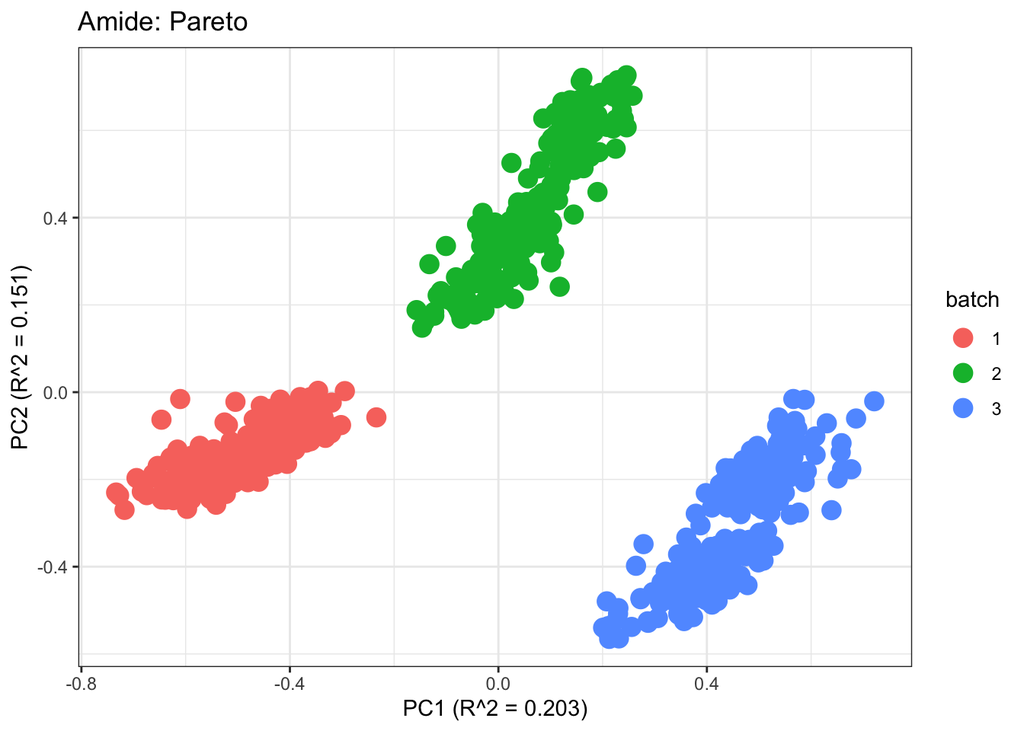

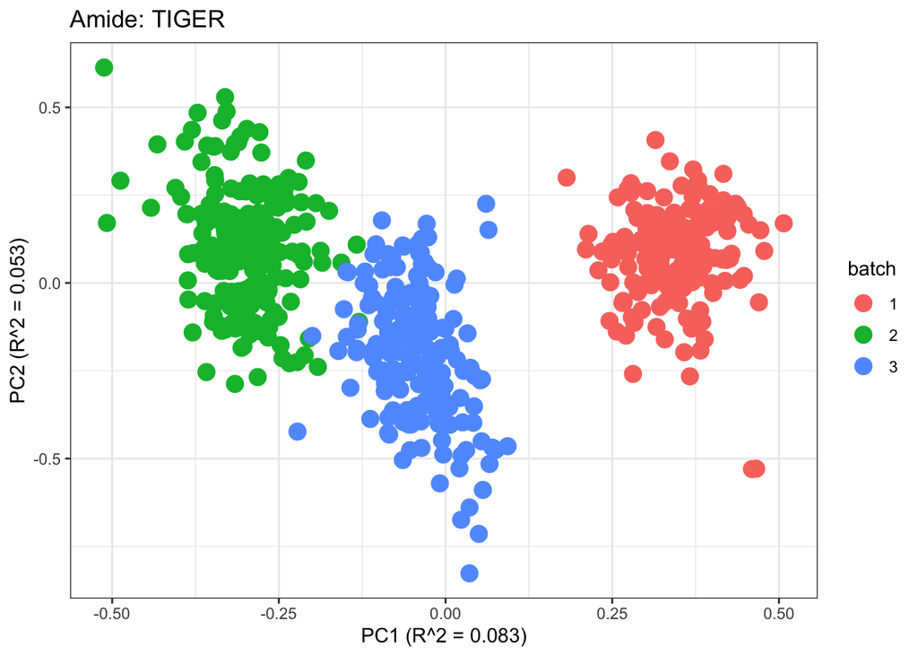

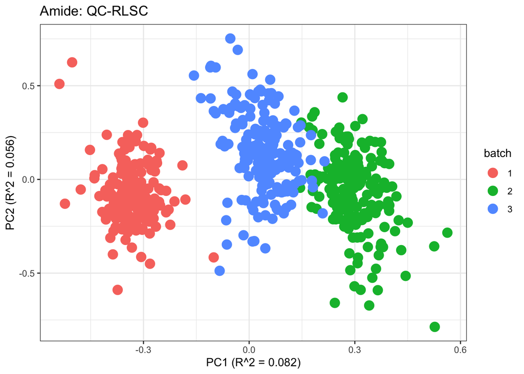

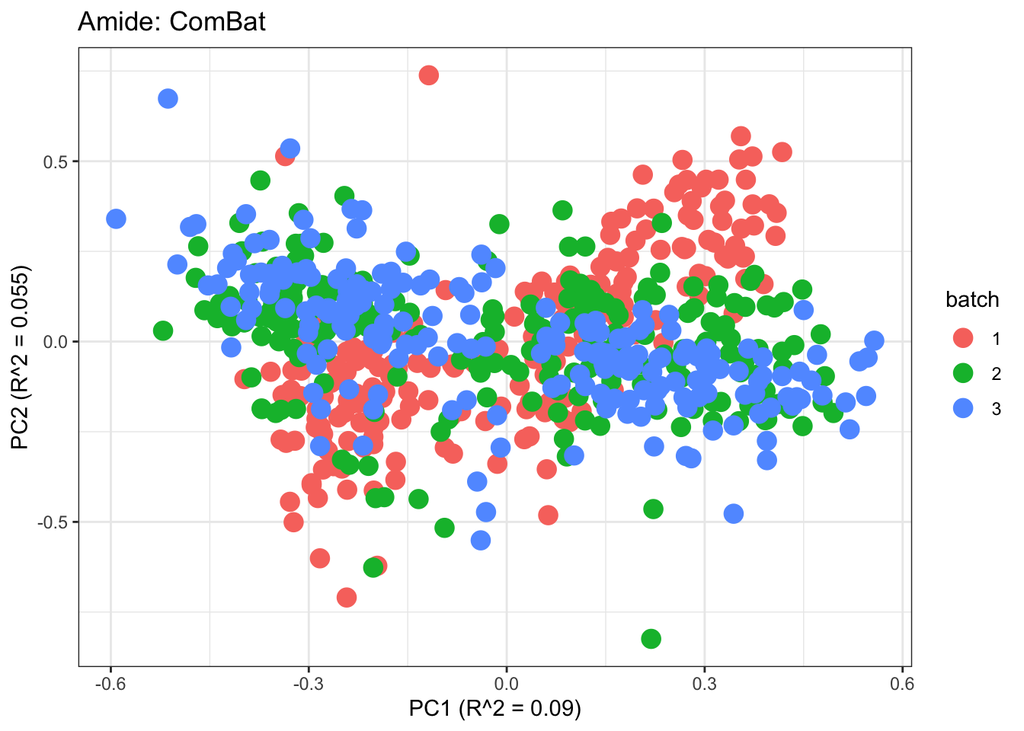

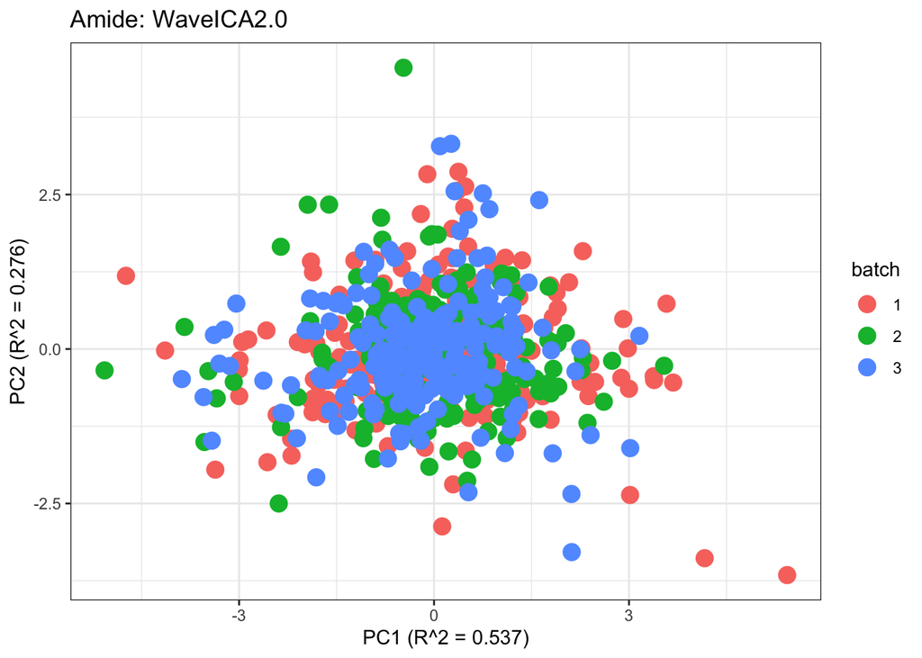

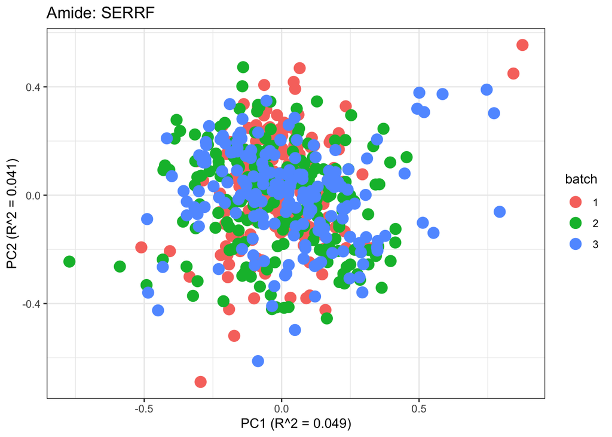

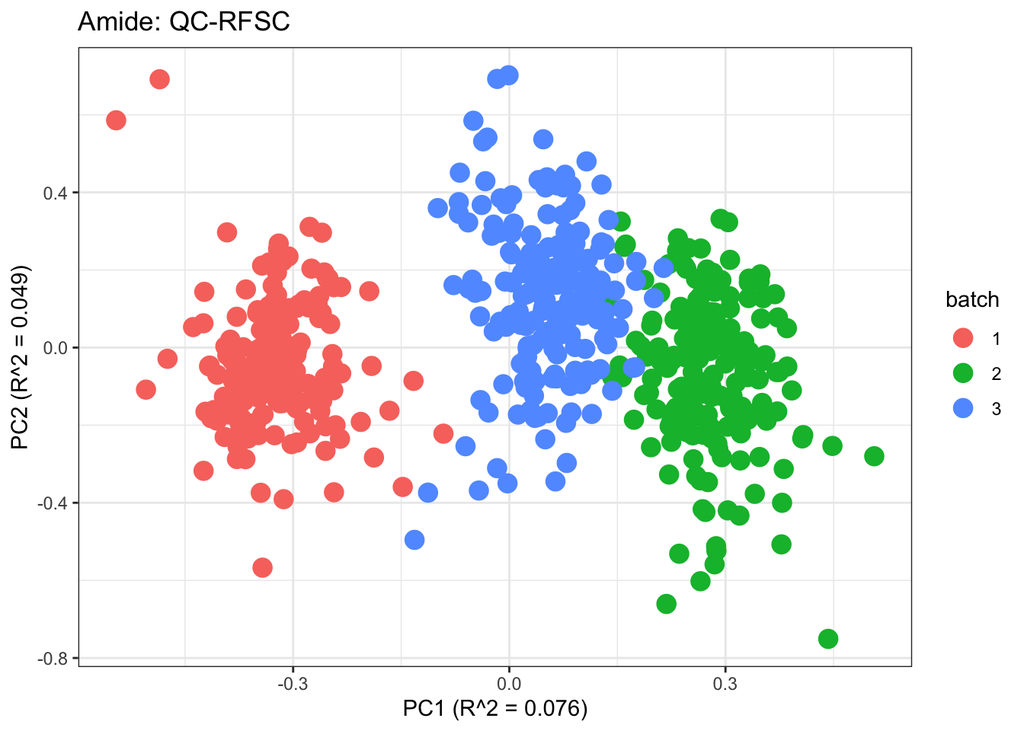

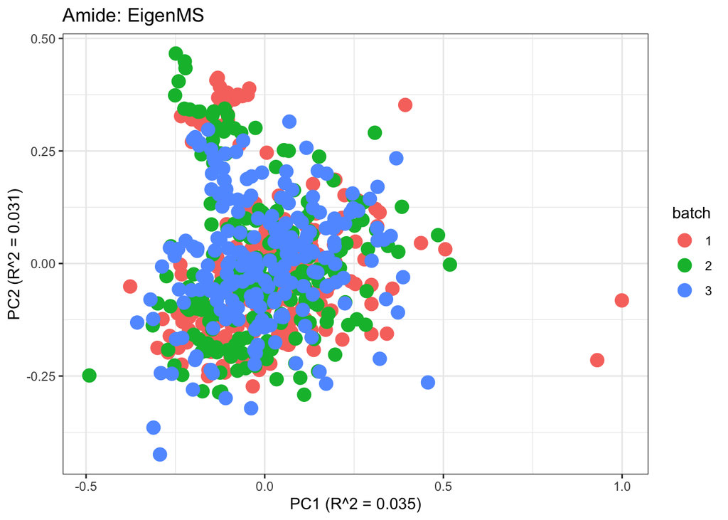

```r
p1 <- plot(dim_reduction(omicsData = pmart_amide_log),omicsData = pmart_amide,color_by = "batch") + labs(title = "Amide: Unadjusted")
p2 <- plot(dim_reduction(omicsData = amide_range),omicsData = amide_range,color_by = "batch") + labs(title = "Amide: Range")
p3 <- plot(dim_reduction(omicsData = amide_power),omicsData = amide_power,color_by = "batch") + labs(title = "Amide: Power")
p4 <- plot(dim_reduction(omicsData = amide_pareto),omicsData = amide_pareto,color_by = "batch") + labs(title = "Amide: Pareto")
p5 <- plot(dim_reduction(omicsData = amide_tiger),omicsData = amide_tiger,color_by = "batch") + labs(title = "Amide: TIGER")
p6 <- plot(dim_reduction(omicsData = amide_qcrlsc),omicsData = amide_qcrlsc,color_by = "batch") + labs(title = "Amide: QC-RLSC")
p7 <- plot(dim_reduction(omicsData = amide_combat),omicsData = amide_combat,color_by = "batch") + labs(title = "Amide: ComBat")
p8 <- plot(dim_reduction(omicsData = amide_wave),omicsData = amide_wave,color_by = "batch") + labs(title = "Amide: WaveICA2.0")
p9 <- plot(dim_reduction(omicsData = amide_serrf),omicsData = amide_serrf,color_by = "batch") + labs(title = "Amide: SERRF")
p10 <- plot(dim_reduction(omicsData = amide_qcrfsc),omicsData = amide_qcrfsc,color_by = "batch") + labs(title = "Amide: QC-RFSC")
p11 <- plot(dim_reduction(omicsData = amide_eigen),omicsData = amide_eigen,color_by = "batch") + labs(title = "Amide: EigenMS")

p1;p2;p3;p4;p5;p6;p7;p8;p9;p10;p11
```

## Data Set 2: Mix Data

We now proceed to the second data set. As not all experiments are designed in the same manner, some batch correction methods may not apply to every data set. `pmart_mix` is based off of the data set `mix` from the `crmn` package (Redestig et al. 2009). This metabolomics data set was ran in three batches. There are 46 molecules and 42 samples. This data set contains sample information regarding batch as well as molecule information regarding internal standards/negative controls.

### Load in the Data

A `pmartR` friendly version of the `mix` data is already implemented within `malbacR`. Therefore, we simply need to load the data.

```r
data(pmart_mix)
```

Before running batch correction, we set the group designation. As there is no group information, we specify the batch number `BatchNum` as both the `main_effects` effect and the `batch_id` as a workaround. Additionally, we create a log2 transformed version of the data as well as a normalized version of the data using global median centering. This data set has no missing values so imputation will not be necessary for any method.

```r
pmart_mix <- group_designation(pmart_mix,main_effects = "BatchNum",batch_id = "BatchNum")
pmart_mix_log <- edata_transform(pmart_mix,"log2")
pmart_mix_norm <- normalize_global(pmart_mix_log,subset_fn = "all",norm_fn = "median",
                                apply_norm = TRUE,backtransform = TRUE)
```

Some methods that have already been demonstrated can be used with this data set as well such as range scaling, power scaling, pareto scaling, and ComBat. There are no QC samples in this data so QC-RLSC, QC-RFSC, TIGER, and SERRF cannot be ran. In addition, there is no injection order information which means that there is insufficient data to run WaveICA2.0. Further there is also no group information (as `BatchNum` was placed as `main_effects` only as a placeholder) and thus EigenMS should not be ran. Additionally, ComBat should be only be ran with batch information and not with group information.

##### Internal Standards/Negative Controls Methods

The two main batch correction methods for this data set are RUV-random and NOMIS. As the data is already complete, there is no need to run imputation. However it is important to note that these methods require complete observations Sysi-Aho et al. (2007). The first method that we use with the “mix” data set is RUV-random which utilizes the function `bc_ruvRandom` and takes the parameters `omicsData`, `nc_cname` (column in `e_meta` which has information on negative controls - here we use the tag for internal standards as negative control), `nc_val` (which is the value within `nc_cname` that is the negative control value), and `k` (the number of factors of unwanted variation)

RUV-random is ran on log2 transformed data that has not been normalized.

```r
mix_ruv <- bc_ruvRandom(omicsData = pmart_mix_log, nc_cname = "tag",nc_val = "IS", k = 3)
```

The other method that uses information found in `e_meta` is NOMIS which uses the function `bc_nomis` and takes the parameters `omicsData`, `is_cname` (column in `e_meta` which has the information on internal standards), `is_val` (the value within `is_cname` that is the value for internal standards) and `num_pc` (number of principal components for NOMIS to consider).

NOMIS is ran on raw abundance values. As there no missing values, data does not need to be imputed. However, if there were missing values, a similar procedure as to what was done with SERRF with the amide data, would be required.

```r
mix_nomis_abundance <- bc_nomis(omicsData = pmart_mix, is_cname = "tag", is_val = "IS", num_pc = 2)
mix_nomis <- edata_transform(omicsData = mix_nomis_abundance, data_scale = "log2")
```

##### Other Methods

We also run applicable methods that were used in the “Amide” data set such as range scaling, pareto scaling, power scaling, and ComBat. Additionally, WaveICA can be ran (just not WaveICA2.0) as it relies on batch information rather than injection order.

```r
mix_combat <- bc_combat(omicsData = pmart_mix_norm)
mix_range <- bc_range(omicsData = pmart_mix_log)
mix_pareto <- bc_pareto(omicsData = pmart_mix_log)
mix_power <- bc_power(omicsData = pmart_mix_log)
mix_waveica_abundance <- bc_waveica(omicsData = pmart_mix,batch_cname = "BatchNum",
                          version = "WaveICA",cutoff_batch = 0.05, cutoff_group = 0.05,
                          negative_to_na = TRUE)
```

[output not shown]

[output cut: 49 more lines]

[output not shown]

```r
mix_waveica <- edata_transform(omicsData = mix_waveica_abundance, data_scale = "log2")
```

### Mix: Data Visualization

Similar to the previous data set, we can compare the PPCA plots between the unadjusted and adjusted data sets. Using the same qualitative logic as with the “Amide” data set, it appears that NOMIS, ComBat, and WaveICA performs well based on the PPCA clustering.

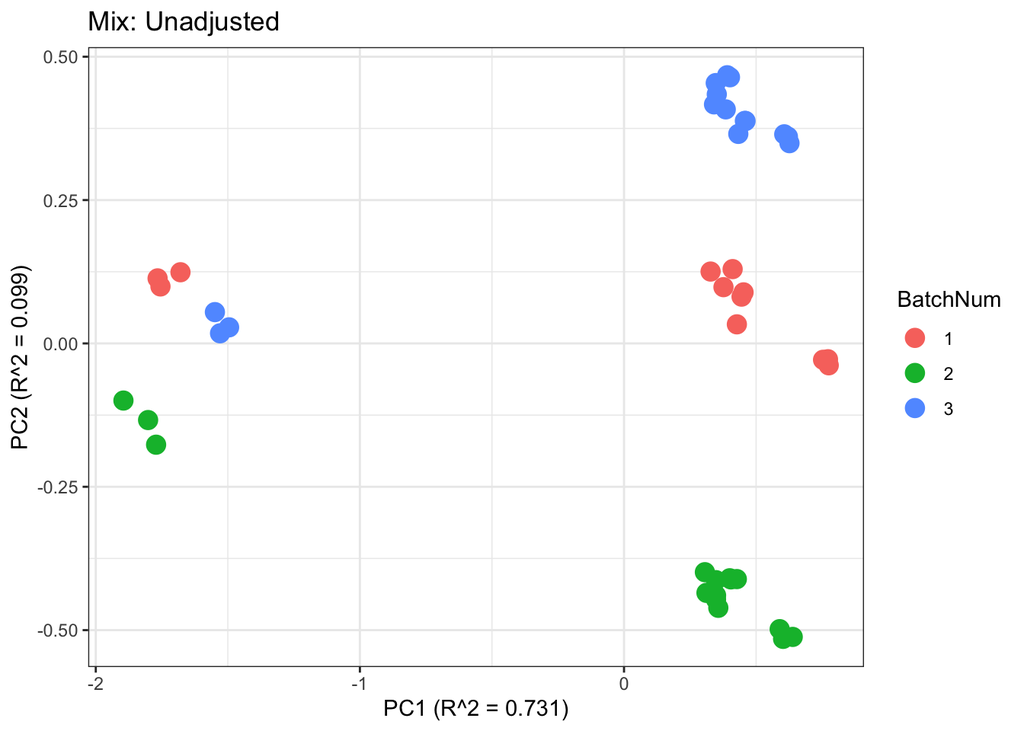

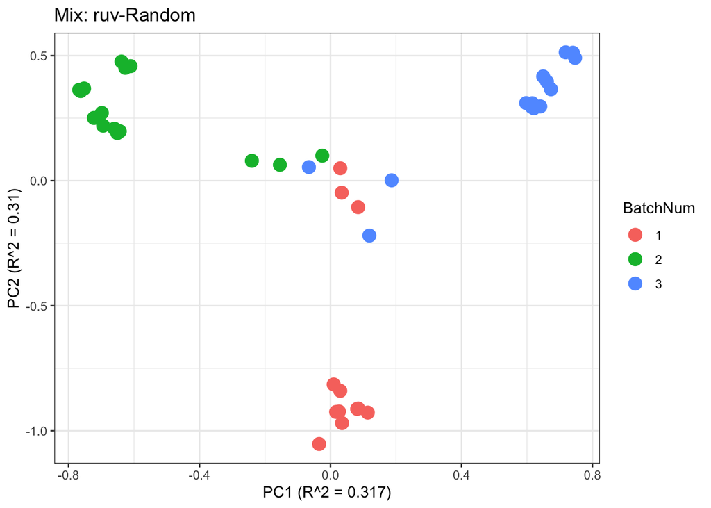

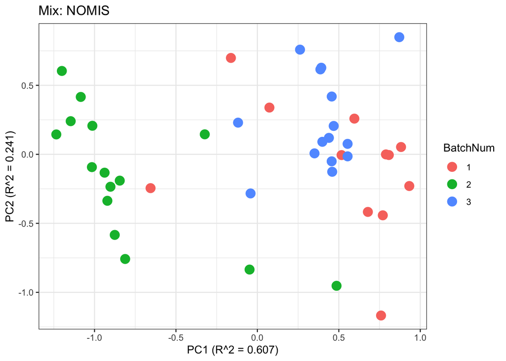

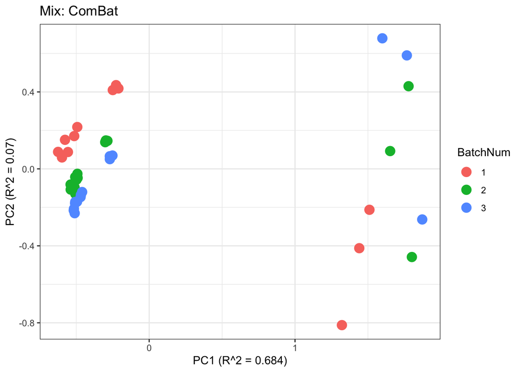

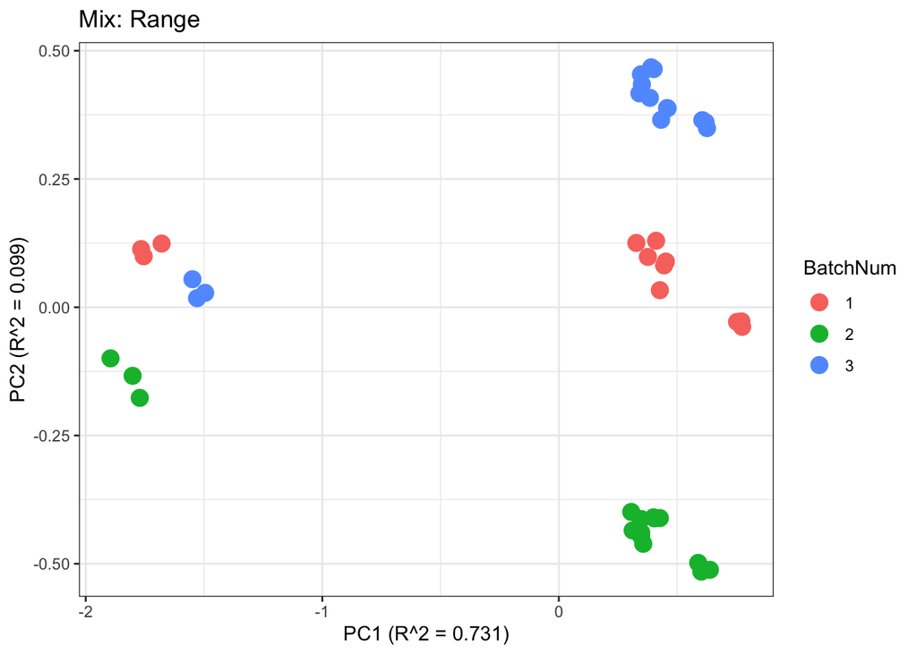

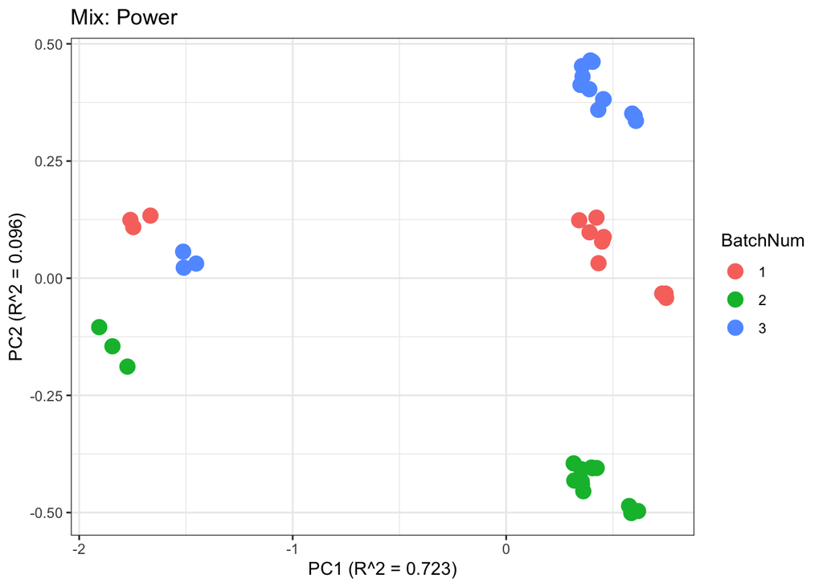

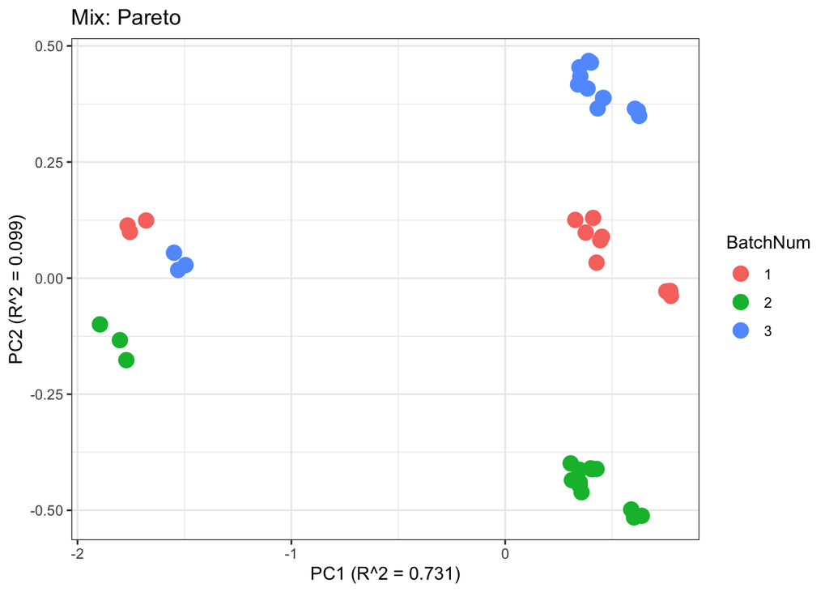

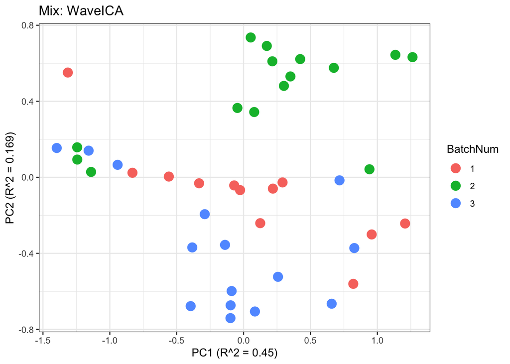

```r
p1 <- plot(dim_reduction(omicsData = pmart_mix_log),omicsData = pmart_mixFilt,color_by = "BatchNum") + labs(title = "Mix: Unadjusted")
p2 <- plot(dim_reduction(omicsData = mix_ruv),omicsData = mix_ruv,color_by = "BatchNum") + labs(title = "Mix: ruv-Random")
p3 <- plot(dim_reduction(omicsData = mix_nomis),omicsData = mix_nomis,color_by = "BatchNum") + labs(title = "Mix: NOMIS")
p4 <- plot(dim_reduction(omicsData = mix_combat),omicsData = mix_combat,color_by = "BatchNum") + labs(title = "Mix: ComBat")
p5 <- plot(dim_reduction(omicsData = mix_range),omicsData = mix_range,color_by = "BatchNum") + labs(title = "Mix: Range")
p6 <- plot(dim_reduction(omicsData = mix_power),omicsData = mix_power,color_by = "BatchNum") + labs(title = "Mix: Power")
p7 <- plot(dim_reduction(omicsData = mix_pareto),omicsData = mix_pareto,color_by = "BatchNum") + labs(title = "Mix: Pareto")
p8 <- plot(dim_reduction(omicsData = mix_waveica),omicsData = mix_pareto,color_by = "BatchNum") + labs(title = "Mix: WaveICA")

p1;p2;p3;p4;p5;p6;p7;p8
```

### References

Berg, Robert A. van der, Huub CJ Hoefsloot, Johan A. Westerhuis, Age K. Smilde, and Mariët J. van der Werf. 2006. “Centering, Scaling, and Transformations: Improving the Biological Information Content of Metabolomics Data.” *BMC Genomics* 1: 142. https://doi.org/10.1186/1471-2164-7-142.

De Livera, Alysha M., Marko Sysi-Aho, Jacob Laurent, Johann A. Gagnon-Bartsch, Sandra Castillo, Julie A. Simpson, and Terence P. Speed. 2015. “Statistical Methods for Handling Unwanted Variation in Metabolomics Data.” *Analytical Chemistry* 87 (7): 3606–15. https://doi.org/10.1021/ac502439y.

Degnan, David J, Kelly G Stratton, Rachel Richardson, Daniel Claborne, Evan A Martin, Nathan A Johnson, Damon Leach, Bobbie-Jo M Webb-Robertson, and Lisa M Bramer. 2023. “pmartR 2.0: A Quality Control, Visualization, and Statistics Pipeline for Multiple Omics Datatypes.” *Journal of Proteome Research* 22 (2): 570–76. https://doi.org/10.1021/acs.jproteome.2c00610.

Deng, Kui, and Kang Li. 2022. *WaveICA2.0: WaveICA 2.0*.

Deng, Kui, Fan Zhang, Qilong Tan, Yue Huang, Zhiwei Rong, Zheng-Jiang Zhu, Kang Li, and Zhenzi Li. 2019. “WaveICA: A Novel Algorithm to Remove Batch Effects for Large-Scale Untargeted Metabolomics Data Based on Wavelet Analysis.” *Analytica Chimica Acta* 1061: 60–69. https://doi.org/10.1016/j.aca.2019.02.010.

Dunn, Warwick B., David Broadhurst, Paul Begley, Eva Zelena, Sue Francis-McIntyrre, Nadine Anderson, Marie Brown, et al. 2011. “Procedures for Large-Scale Metabolic Profiling of Serum and Plasma Using Gas Chromatography and Liquid Chromatography Coupled to Mass Spectrometry.” *Nature Protocols* 6 (7): 1060–83. https://doi.org/10.1038/nprot.2011.335.

Fan, Sili, Tobias Kind, Tomas Cajka, Stanley L. Hazen, H. W. Wilson Tang, Rima Kaddurah-Daouk, Marguerite R. Irvin, Donna K. Arnett, Dinesh K. Barupal, and Oliver Fiehn. 2019. “Systematic Error Removal Using Random Forest for Normalizing Large-Scale Untargeted Lipidomics Data.” *Analytical Chemistry* 91 (5): 3590–96. https://doi.org/10.1021/acs.analchem.8b05592.

Han, Siyu, Jialing Huang, Francesco Foppiano, Cornelia Prehn, Jerzy Adamski, Karsten Suhre, Ying Li, et al. 2022. “TIGER: Technical Variation Elimination for Metabolomics Data Using Ensemble Learning Architecture.” *Briefings in Bioinformatics* 23 (2). https://doi.org/10.1093/bib/bbab535.

Karpievitch, Yuliya V., Sonja B. Nikolic, Richard Wilson, James E. Sharman, and Lindsay M. Edwards. 2014. “Metabolomics Data Normalization with EigenMS.” *PLOS ONE* 9 (12). https://doi.org/10.1371/journal.pone.0116221.

Luan, Hemi, Fenfen Ji, Yu Chen, and Zongwei Cai. 2018. “statTarget: A Streamlined Tool for Signal Drift Correction and Interpretations of Quantitative Mass Spectrometry-Based Omics Data.” *Analytica Chimica Acta* 1036: 66–72. https://doi.org/10.1016/j.aca.2018.08.002.

Müller, Christian, Arne Schillert, Caroline Röthmeier, David-Alexandre Trégouët, Caroline Proust, Harald Binder, Norbert Pfeiffer, et al. 2016. “Removing Batch Effects from Longitudinal Gene Expression - Quantile Normalization Plus ComBat as Best Approach for Microarray Transcriptome Data.” *PLOS ONE* 11 (6). https://doi.org/10.1371/journal.pone.0156594.

Redestig, Henning, Atsushi Fukushima, Hans Stenlund, Thomas Moritz, Masanori Arita, Kazuki Saito, and Miyako Kusano. 2009. “Compensation for Systematic Cross-Contribution Improves Normalization of Mass Spectrometry Based Metabolomics Data.” *Analytical Chemistry* 81: 7974–80.

Stratton, Kelly G, Bobbie-Jo M Webb-Robertson, Lee Ann McCue, Daniel Claborne, Bryan Stanfill, Iobani Godinez, Thomas Johansen, et al. 2019. “pmartR: Quality Control and Statistics for Mass Spectrometry-Based Biological Data.” *Journal of Proteome Research*.

Sysi-Aho, Marko, Mikko Katajamaa, Laxman Yetukuri, and Matej Orešič. 2007. “Normalization Method for Metabolomics Data Using Optimal Selection of Multiple Internal Standards.” *BMC Bioinformatics* 8: 93. https://doi.org/10.1186/1471-2105-8-93.

Webb-Robertson, Bobbie-Jo M, Melissa M Matzke, Thomas O Metz, Jason E McDermott, Hyunjoo Walker, Karin D Rodland, Joel G Pounds, and Katrina M Waters. 2013. “Sequential Projection Pursuit Principal Component Analysis–Dealing with Missing Data Associated with New-Omics Technologies.” *Biotechniques* 54 (3): 165–68.

Webb-Robertson, Bobbie-Jo, Melissa M. Matzke, Jon M. Jacobs, Joel G. Pounds, and Katrina M. Water. 2011. “A Statistical Selection Strategy for Normalization Procedures in LC‐MS Proteomics Experiments Through Dataset‐dependent Ranking of Normalization Scaling Factors.” *Proteomics* 11 (24): 4736–41. https://doi.org/10.1002/pmic.201100078.